# Actuariat : Combinaison d'algorithmes pour modéliser une prime

## Samuel Lauras

*Université Paris Dauphine (PSL)*  
1/10/2025

Vous trouverez ci-dessous un notebook proposant une première modélisation d'une prime d'une garantie auto Chaque ligne correspond à une exposition annuelle au risque Parmi les variables à expliquer :

CHARGE => charge de sinistralité annuelle

NB => Nombre de sinistres sur la période de l'année couverte

EXPO => la durée annuelle d'exposition au risque

FREQ => NB/EXPO

COUT_MOYEN => COUT/NB

Les autres variables sont les variables explicatives avec pour toute variable X_PREC = 1 s'il y a eu un sinistre sur la garantie X par le passé

Votre objectif est de faire évoluer l'ensemble du notebook pour optimiser deux métriques sur la base de test :

**Métrique 1** : Minimisation de l'erreur quadratique moyenne de la prime

**Métrique 2** : Convergence du ratio Sinistres/Primes vers 1

La proposition ci-dessous ne tient pas compte de la variable EXPO, libre à vous de l'intégrer ou non aux travaux. Le fait de ne pas considérer la variable EXPO ne sera pas évalué et ne sera donc pas pénalisant

Vous pouvez opter pour l'une des stratégies suivantes :

**Stratégie 1** : Modélisation FREQ * COUT_MOYEN

**Stratégie 2** : Modélisation PROBA_SINISTRE * COUT où la variable COUT = CHARGE > 0

**Stratégie 3** : Modélisation directement de la charge

## ATTENTION Certains blocs de code ci-dessous ne doivent pas être modifiés

Via le libellé "Ne pas changer le bloc ci-dessous", il vous faudra juste comprendre et exécuter le bloc qui suit. A la lecture de ces blocs, vous comprendrez qu'il s'agira de benchmarker votre modélisation

## VOTRE RENDU

Merci de respecter les consignes suivantes :

**Ce notebook complété** : des codes, des commentaires et des résultats obtenus

**Un page A4 au format PDF** : recensant l'ensemble des modèles testés et résultats obtenus ainsi que les next steps à envisager

De manière facultative :

**Un 2nd notebook** : si vous hésitez entre deux modèles lors de l'analyse de vos résultats

**Tout reporting** : se reportant à la préparation de la donnée ou autre

```python
%load_ext autoreload
%autoreload 2
```

```python
import numpy as np
import pandas as pd
from matplotlib import pyplot as plt
import seaborn as sns

import plotly.express as px

from ModelMonitoring import ModelMonitoring

from visualisation import (
    plot_law_density,
    plot_law_qq,
    plot_regression_diagnostics,
    plot_classification_diagnostics,
    plot_importance
)
```

```python
bdd = pd.read_csv('./db_auto_dm_2025.csv',sep=";")
bdd.info(verbose=True, show_counts=True)
```

```
<class 'pandas.core.frame.DataFrame'>
RangeIndex: 39944 entries, 0 to 39943
Data columns (total 29 columns):
 #   Column             Non-Null Count  Dtype
---  ------             --------------  -----
 0   Unnamed: 0         39944 non-null  int64
 1   CHARGE             39944 non-null  float64
 2   NB                 39944 non-null  int64
 3   EXPO               39944 non-null  float64
 4   FREQ               39944 non-null  float64
 5   COUT_MOYEN         39944 non-null  float64
 6   ANNEE_EXPO         39944 non-null  int64
 7   ANNEE_VEHICULE     39944 non-null  int64
 8   ZONE_RISQUE        39944 non-null  object
 9   AGE_ASSURE         39944 non-null  object
```

[output cut: 21 more lines]

```python
bdd2 = bdd.iloc[:,1:].copy()
```

```python
px.histogram(bdd2.loc[bdd2['CHARGE']>0, 'CHARGE'],nbins=200)
```

[output not shown]

Donnees très éparses, concentrés sur la première partie de la distribution

Ratio du nombre de contrats, avec une 'charge' > 20k :

```python
bdd2.loc[bdd2.CHARGE > 20000,'CHARGE'].count()/bdd2['CHARGE'].count()
```

```
0.0008011215701982776
```

Part de representation de ces outliers dans la somme des charges :

```python
bdd2.loc[bdd2.CHARGE > 20000,'CHARGE'].sum()/bdd2['CHARGE'].sum()
```

```
0.15731558738414747
```

Différence de prime "moyennenisée", entre les >20k et <20k ; un facteur 5 les sépare

```python
bdd2.loc[bdd2.CHARGE > 20000,'CHARGE'].sum()/bdd2['EXPO'].sum()
```

```
29.08763241187885
```

```python
bdd2.loc[bdd2.CHARGE <= 20000,'CHARGE'].sum()/bdd2['EXPO'].sum()
```

```
155.8122423910549
```

# Préparation des données

```python
# Ne pas modifier
bdd3 = bdd2.loc[bdd2.CHARGE < 20000]
features = bdd3.drop(columns=['CHARGE','NB','EXPO','COUT_MOYEN','FREQ'])
couts = np.asarray(bdd3['CHARGE'])
y = couts.copy()
y[y>0] = 1
expos = bdd3[['EXPO']]
```

## Analyse descriptives et data engineering

```python
#from ydata_profiling import ProfileReport

#profile = ProfileReport(bdd3, title="prime-auto.html")

#profile.to_file(output_file='rapport-prime-auto.html')
```

```python
def summarize_categoricals(df: pd.DataFrame) -> pd.DataFrame:
    def top3_distrib(series: pd.Series) -> list[str | None]:
        value_counts = series.value_counts(normalize=True)
        top3 = value_counts.head(3)
        return [f"{idx} ({round(pct*100,2)}%)" for idx, pct in top3.items()] + [None]*(3-len(top3))

    data = [[
        df[c].unique(),
        len(df[c].unique()),
        df[c].isnull().sum(),
        np.round((df[c].isnull().sum() / df.shape[0]) * 100, 1),
        df.dtypes[c],
        *top3_distrib(df[c])
    ] for c in df.columns]
    df_temp = pd.DataFrame(data, index=df.columns,
                        columns=['Levels', 'No. of Levels', 'No. of Missing Values', '% empty', 'type',
                                 'Top1', 'Top2', 'Top3'])
    return df_temp

summarize_categoricals(bdd3.round(2))
```

|  | Levels | No. of Levels | No. of Missing Values | % empty | type | Top1 | Top2 | Top3 |
| --- | --- | --- | --- | --- | --- | --- | --- | --- |
| CHARGE | [4121.41, 0.0, 2500.0, 5697.29, 105.3, 111.15,... | 1582 | 0 | 0.0 | float64 | 0.0 (94.67%) | 2500.0 (0.24%) | 105.3 (0.18%) |
| NB | [1, 0, 2] | 3 | 0 | 0.0 | int64 | 0 (94.67%) | 1 (5.1%) | 2 (0.24%) |
| EXPO | [1.0, 0.24, 0.86, 0.42, 0.99, 0.98, 0.06, 0.83... | 101 | 0 | 0.0 | float64 | 1.0 (48.17%) | 0.83 (9.04%) | 0.5 (0.8%) |
| FREQ | [1.0, 0.0, 3.3, 8.49, 1.34, 1.23, 1.11, 2.87, ... | 244 | 0 | 0.0 | float64 | 0.0 (94.67%) | 1.0 (3.05%) | 1.2 (0.24%) |
| COUT_MOYEN | [4121.41, 0.0, 2500.0, 2848.64, 105.3, 111.15,... | 1580 | 0 | 0.0 | float64 | 0.0 (94.67%) | 2500.0 (0.25%) | 105.3 (0.19%) |
| ANNEE_EXPO | [2021, 2022, 2024, 2023, 2020, 2019] | 6 | 0 | 0.0 | int64 | 2023 (19.21%) | 2022 (18.86%) | 2021 (17.16%) |
| ANNEE_VEHICULE | [2019, 2020, 2018, 2016, 2013, 2017, 2022, 201... | 19 | 0 | 0.0 | int64 | 2019 (25.44%) | 2018 (13.73%) | 2016 (13.13%) |
| ZONE_RISQUE | [D, B, C, E, A, G, J, K, H] | 9 | 0 | 0.0 | object | D (39.59%) | C (27.14%) | B (25.25%) |
| AGE_ASSURE | [(45,55], (55,65], (40,45], (65,75], (35,40], ... | 7 | 0 | 0.0 | object | (45,55] (31.26%) | (55,65] (21.43%) | (40,45] (12.82%) |
| ANCIENNETE_PERMIS | [(25,60], (12,25], (8,12], (4,6], (6,8], (2,4]... | 8 | 0 | 0.0 | object | (25,60] (76.49%) | (12,25] (18.29%) | (8,12] (3.34%) |
| ANCIENNETE_ASSURE | [(1,2], (-1,0], (0,1], (2,5], (5,10]] | 5 | 0 | 0.0 | object | (0,1] (30.14%) | (-1,0] (25.67%) | (2,5] (22.72%) |
| GENRE_ASSURE | [M, F] | 2 | 0 | 0.0 | object | M (56.53%) | F (43.47%) | None |
| NB_KM | [(5k,15k], (15k,30k], (30k,40k], (40k,60k], (5... | 7 | 0 | 0.0 | object | (5k,15k] (54.92%) | (15k,30k] (30.21%) | (30k,40k] (7.77%) |
| SECOND_CONDUCTEUR | [NON, nan, OUI] | 3 | 24413 | 61.2 | object | OUI (50.2%) | NON (49.8%) | None |
| FORMULE | [L1, L3, L4, L2, L5] | 5 | 0 | 0.0 | object | L1 (99.66%) | L3 (0.2%) | L2 (0.12%) |
| MODALITE_PAIEMENT | [MENSUEL, TRIMESTRIEL, ANNUEL] | 3 | 0 | 0.0 | object | MENSUEL (47.51%) | ANNUEL (40.93%) | TRIMESTRIEL (11.56%) |
| AGE_VEHICULE_ | [(1,2], (-1,0], (0,1], (3,4], (2,3], (5,6], (4... | 10 | 0 | 0.0 | object | (1,2] (17.67%) | (0,1] (17.58%) | (2,3] (16.06%) |
| ENERGIE_ | [DIESEL, ESSENCE, AUTRE] | 3 | 0 | 0.0 | object | ESSENCE (51.58%) | DIESEL (47.66%) | AUTRE (0.75%) |
| NIVEAU_ANTIVOL | [1, 2, 3, 4, 5] | 5 | 0 | 0.0 | int64 | 1 (65.31%) | 2 (34.55%) | 3 (0.12%) |
| PUISSANCE | [(110,130], (130,700], (95,110], (80,85], (90,... | 10 | 0 | 0.0 | object | (85,90] (17.02%) | (110,130] (13.04%) | (130,700] (13.02%) |
| VALEUR_VEHICULE | [(35k,80k], (22k,25k], (25k,35k], (16k,18k], (... | 10 | 0 | 0.0 | object | (35k,80k] (14.01%) | (25k,35k] (12.9%) | (22k,25k] (12.24%) |
| LEASING | [NON, OUI] | 2 | 0 | 0.0 | object | NON (95.36%) | OUI (4.64%) | None |
| POIDS_PUISSANCE | [(17,18], (15,16], (13,15], (10,13], (0,10], (... | 9 | 0 | 0.0 | object | (10,13] (15.75%) | (16,17] (15.19%) | (15,16] (14.29%) |
| RC_PREC_AN1 | [0.0, 1.0] | 2 | 0 | 0.0 | float64 | 0.0 (97.07%) | 1.0 (2.93%) | None |
| RC_PREC_AN2 | [0.0, 1.0] | 2 | 0 | 0.0 | float64 | 0.0 (98.26%) | 1.0 (1.74%) | None |
| DM_PREC | [0.0, 1.0] | 2 | 0 | 0.0 | float64 | 0.0 (99.1%) | 1.0 (0.9%) | None |
| BIV_PREC | [0.0, 1.0] | 2 | 0 | 0.0 | float64 | 0.0 (99.22%) | 1.0 (0.78%) | None |
| ZONE_GEO | [62, 84, 85, 58, 48, 54, 26, 10, 56, 35, 71, 2... | 66 | 0 | 0.0 | int64 | 87 (12.72%) | 74 (10.75%) | 56 (8.02%) |

## zoom sur les changements structurels du dataset

### Données manquantes :

- SECOND_CONDUCTEUR : 24413 missing values (61.2%)

### Mauvais types :

interpreation en classes

valiarbles 0 ou 1

- RC_PREC_AN1 : int -> to object,
- RC_PREC_AN2 : int -> to object,
- DM_PREC : int -> to object,
- BIV_PREC : int -> to object

### Variables déséquilibrées :

-> Choisir un KFOLD **stratifié**

- NB is highly imbalanced (80.2%)
- ANCIENNETE_PERMIS is highly imbalanced (65.3%)
- FORMULE is highly imbalanced (98.4%)
- NIVEAU_ANTIVOL is highly imbalanced (59.3%)
- LEASING is highly imbalanced (72.9%)
- RC_PREC_AN1 is highly imbalanced (80.9%)
- RC_PREC_AN2 is highly imbalanced (87.3%)
- DM_PREC is highly imbalanced (92.6%)
- BIV_PREC is highly imbalanced (93.4%)

### warnings, valeurs nulles :

- CHARGE has 37783 zeros(94.7%)
- FREQ has 37783 zeros (94.7%)
- COUT_MOYEN has 37783 zeros (94.7%)

- pour les zones géo, car on veut que chaque régions aient son propre coefficient.
- pour l'année d'exposition, même chose, on souhaite que le modèle détermine lui-même le coefficient (si une année exposée est plus favorable aux primes par exemple)

```python
bdd4 = bdd3.copy()

# Convertir les colonnes en string

for col in ["ZONE_GEO", "ANNEE_EXPO"]:
    bdd4[col] = bdd4[col].astype("object")

for col in ["RC_PREC_AN1", "RC_PREC_AN2", "DM_PREC", "BIV_PREC"]:
    bdd4[col] = bdd4[col].astype("object")
```

## Annalyse des correlations

### Quantilisation (binning)

Nous allons utiliser un diagramme de correlation de pearson (similair au v de cramer)

Pour ce faire nous avons besoin de quantiliser nos variables quantitatives (ici déciles)

```python
def num_to_cat(df_:pd.DataFrame, q=10, ignore_int=True, verbose=False)->pd.DataFrame:
    """ Convertit les variables numériques en déciles (catégorielles)"""
    df = df_.copy()
    for column in df.select_dtypes(include=['float64' if ignore_int else 'number']).columns:
        col = df[column]
        # découpe en 9 déciles en excluant les 0
        deciles, bins = pd.qcut(col.loc[col != 0], q=q-1, labels=False, retbins=True, duplicates='drop', precision=8)
        bins = [round(float(x), 2) for x in bins]
        # imperatif d'afficher les bins pour debug
        print(f"Converting {column} , déciles utilisés: {bins}")
        # inclure 0 dans le premier décile
        deciles = deciles +1
        bins = [0] + bins
        # créer une série avec les mêmes index que col, initialisée à "0"
        result = pd.Series("[0]", index=col.index)
        # créer les labels des déciles
        decile_labels = [f"({round(bins[i],1)},{round(bins[i+1],1)}]" for i in range(len(bins)-1)]
        # affecter noms de déciles aux individus
        result.loc[col != 0] = deciles.map(lambda d: decile_labels[int(d)] if pd.notnull(d) else d).values
        if verbose:
            print(result.value_counts())
        df[column] = result

    if ignore_int:
        for col in df.select_dtypes(include=['int']).columns:
            print(f"Converting {col} (int) directly to object")
            df[col] = df[col].astype('object')
    return df
```

```python
categorical_df = num_to_cat(bdd4,q=20, ignore_int=True)
```

```
Converting CHARGE , déciles utilisés: [0.81, 109.98, 117.0, 279.46, 491.7, 672.19, 829.43, 1009.49, 1199.56, 1382.31, 1602.17, 1834.41, 2142.78, 2500.0, 2610.22, 3124.1, 3801.89, 4889.37, 7609.06, 19449.3]
Converting EXPO , déciles utilisés: [0.0, 0.15, 0.29, 0.43, 0.54, 0.64, 0.74, 0.83, 0.83, 0.88, 1.0, 1.0, 1.0]
Converting FREQ , déciles utilisés: [1.0, 1.0, 1.0, 1.02, 1.16, 1.2, 1.38, 1.57, 1.94, 2.17, 3.21, 243.33]
Converting COUT_MOYEN , déciles utilisés: [0.81, 109.98, 117.0, 276.28, 479.57, 663.88, 819.97, 982.59, 1155.4, 1338.28, 1551.91, 1773.11, 2012.27, 2421.1, 2500.0, 2905.88, 3514.47, 4623.81, 7367.07, 19449.3]
Converting NB (int) directly to object
Converting ANNEE_VEHICULE (int) directly to object
Converting NIVEAU_ANTIVOL (int) directly to object
```

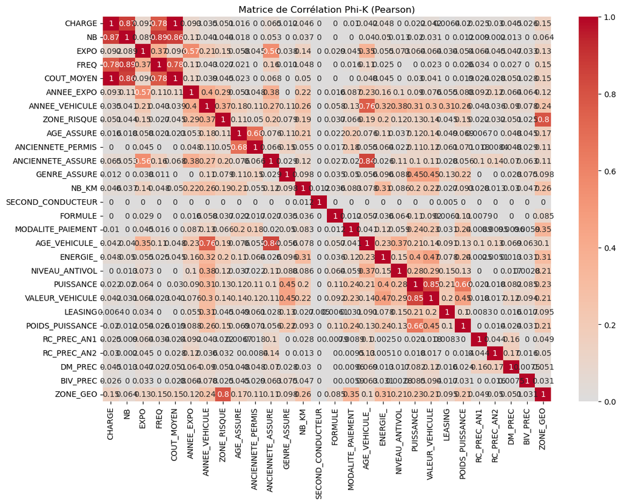

```python
from phik import phik_matrix

corr_matrix = phik_matrix(categorical_df)

plt.figure(figsize=(13, 9))
sns.heatmap(corr_matrix, annot=True, cmap="coolwarm", center=0)
plt.title("Matrice de Corrélation Phi-K (Pearson)")
plt.show()
```

# Analyse du modèle linéaire

## Mise en route du modèle linéaire généralisé

Etant donné que l'utilisation de modèles linéaires dans le secteur financier est très important. Donnons une analyse plus poussée de celui-ci.

On s'assure d'une loi qui resprésnte les données.

## Ajustement à une loi, KS-bootstrap

Le test de Kolmogorov–Smirnov nous donne une statistique qui mesure l'équart entre deux distributions.

1. On pose un test d'hypothese : $ H_0 \text{vs} H_1$
2. On part d'une loi connue, où on ajuste ses paramètres $\theta$ (par Maximum de vraissemblance)
3. On compare la statistique D, on rejete ou non statistiqueemnt l'hypothese

Problème : en pratique, on estime $\theta$ à partir des données (ex. via Maximum de Vraisemblance). Résultat : la distribution nulle du test de base n’est plus la loi KS standard (Kolmogorov distribution).

- -> Le test devient trop « sévère » où les p-values ≈ 0 même si le modèle est bon

L'idée est donc de faire du **bootstrap parametrique** pour contourner ce biais

1. On calcule la satistique de test classique
2. On simule plein de jeux de données depuis la loi ajustée aux données (par MLE)
3. Pour chaque jeu simulé, on ré-estime les paramètres
4. On calcule la statistique KS pour chaque jeu simulé
5. Calculer la p-value bootstrap (de l'ensemble des tests simulés)

## Modélisation avec la loie Gamma

- ->Nous prendrons la loi Gamma, connue en actuariat pour modéliser les coûts.

```python
from scipy import stats
```

```python
data = couts[couts > 0]
```

```python
def bootstrap_kstest(data, dist, n_boot=1000, random_state=None):
    rng = np.random.default_rng(random_state)
    data = np.asarray(data)
    n = data.size

    # 1) fit la distribution aux données (MLE)
    fitted_params = dist.fit(data)
    # statistique de test (classical)
    ks_obs, p_classical = stats.kstest(data, dist.name, args=fitted_params)

    # 2) bootstrap
    ks_boot = np.empty(n_boot)
    for i in range(n_boot):
        # simuler de nouveaux échantillons à partir de la distribution ajustée
        sim = dist.rvs(*fitted_params, size=n, random_state=rng)
        # re-fit parametres sur les echantillons simulés
        params_sim = dist.fit(sim)
        # calculer la statistique KS pour l'échantillon simulé par rapport à sa CDF ajustée
        ks_boot[i] = stats.kstest(sim, dist.name, args=params_sim)[0]

    # bootstrap p-value: proportion de bootstrap KS >= KS observé
    p_boot = (np.sum(ks_boot >= ks_obs) + 1) / (n_boot + 1)

    print("fit params:", fitted_params)
    print("Statistique de test (KS obs) =", ks_obs)
    print("p-value classique =", p_classical)
    print("p-value bootstrap =", p_boot)
    print("nombre d'échantillons bootstrap >= ks_obs =", np.sum(ks_boot >= ks_obs), "sur 1000")

    return {"ks_obs": ks_obs, "p_classical": p_classical, "p_bootstrap": p_boot,
            "fitted_params": fitted_params, "nb_ks_boot": np.sum(ks_boot >= ks_obs)}
```

**Hypothèse du test de Kolmogorov-Smirnov :**

- $H_0$ : Le coût d'un sinistre suit une loi Gamma.
- $H_1$ : Le coût dun sinistre ne suit pas une loi Gamma.

```python
res_gamma = bootstrap_kstest(data, stats.gamma, n_boot=1000, random_state=123)
```

```
fit params: (0.9076565691808591, -0.14547432636607982, 2465.9100308348907)
Statistique de test (KS obs) = 0.06619198040742565
p-value classique = 1.4880660365412044e-08
p-value bootstrap = 0.26873126873126874
nombre d'échantillons bootstrap >= ks_obs = 268 sur 1000
```

**Hypothèse du test de Kolmogorov-Smirnov :**

```python
res_lognorm = bootstrap_kstest(data, stats.lognorm, n_boot=1000, random_state=123)
```

```
fit params: (1.1451131214578123, -65.29514652052742, 1330.9763518012803)
Statistique de test (KS obs) = 0.08927494467287353
p-value classique = 3.251538516830361e-15
p-value bootstrap = 0.000999000999000999
nombre d'échantillons bootstrap >= ks_obs = 0 sur 1000
```

| Distribution | KS Observed | p-value (bootstrap) |
| --- | --- | --- |
| Gamma | 0.0662 | 0.269 |
| Log-Normal | 0.0893 | 0.001 |

Ces résultats révèlent qu’au seuil de 5%, on ne peut rejeter l’hypothèse nulle selon laquelle le coût d'un sinistre est distribué selon une loi Gamma.

Cependant, ces derniers suggèrent qu’on peut fortement rejeter l’hypothèse selon laquelle elle distribué selon une loi Log-normale.

L'analyses graphique et numériques suivantes permettent d’évaluer le niveau d’adéquation qui pourrait exister entre la distribution des coûts et la loi Gamma.

```python
fitted_params_gamma = res_gamma["fitted_params"]
gamma_theoretical = stats.gamma(*fitted_params_gamma)
plot_law_density(data, gamma_theoretical, "Gamma")
```

[output not shown]

```python
plot_law_qq(data, gamma_theoretical, "variable cible vs loi Gamma")
```

[output not shown]

## Choisir à votre convenance le format de chaque colonne

## Split des données en base de test et bases de validation

```python
# Ne pas modifier
from sklearn.model_selection import train_test_split, KFold

#features = bdd4.drop(columns=['CHARGE','NB','EXPO','COUT_MOYEN','FREQ'])

X = features.copy()
X_train, X_test, couts_train, couts_test, y_train, y_test = train_test_split(X, couts, y,  test_size=0.2, random_state=3)

kf = KFold(n_splits=4, shuffle=True, random_state=2)
les_splits = []

for train_index, valid_index in kf.split(X_train):
    les_splits.append([train_index, valid_index])

les_splits
```

```
[[array([    1,     3,     4, ..., 31925, 31926, 31928]),
  array([    0,     2,     6, ..., 31917, 31923, 31927])],
 [array([    0,     2,     3, ..., 31926, 31927, 31928]),
  array([    1,     4,     5, ..., 31918, 31919, 31921])],
 [array([    0,     1,     2, ..., 31923, 31925, 31927]),
  array([    3,     7,    14, ..., 31924, 31926, 31928])],
 [array([    0,     1,     2, ..., 31926, 31927, 31928]),
  array([    9,    12,    13, ..., 31912, 31922, 31925])]]
```

```python
# a été réécrit

# Séparer les colonnes numériques et catégorielles
variables_num = features.select_dtypes(exclude="object").columns.to_list()
variables_cat = features.select_dtypes(include="object").columns.to_list()

# # Récupérer les indices
# numeric_indices = [i for i, col in enumerate(features.columns) if col in variables_num]
# categorical_indices = [i for i, col in enumerate(features.columns) if col in variables_cat]

# categorical_indices, numeric_indices
```

## Préprocessing

```python
from sklearn.pipeline import Pipeline
from sklearn.preprocessing import StandardScaler, OneHotEncoder, FunctionTransformer
from sklearn.compose import ColumnTransformer
from sklearn.impute import SimpleImputer

# Créer un ColumnTransformer pour l'imputation et le prétraitement des variables
preprocessor = ColumnTransformer(
    transformers=[
        ('num', Pipeline([
            ('imputer', SimpleImputer(strategy='median')),
            ('scaler', StandardScaler())
        ]), variables_num),
        ('cat', Pipeline([
            ('imputer', SimpleImputer(strategy='most_frequent', fill_value='missing')),
            ('onehot', OneHotEncoder(handle_unknown='ignore', sparse_output=False, drop=None))
        ]), variables_cat)
    ])
```

```python
column_transformer = preprocessor.fit(X)
```

```python
cat_feature_names = list(column_transformer.named_transformers_['cat'].named_steps['onehot']\
                            .get_feature_names_out(input_features=variables_cat))
feature_names = variables_num + cat_feature_names
```

```python
# vérification des dimensions
print("nombre de colonnes après encodage :", len(feature_names), "verification:", column_transformer.transform(X.iloc[[0]]).shape[1])
```

```
nombre de colonnes après encodage : 100 verification: 100
```

```python
pd.DataFrame(preprocessor.fit_transform(X), columns=feature_names)
```

|  | ANNEE_EXPO | ANNEE_VEHICULE | NIVEAU_ANTIVOL | RC_PREC_AN1 | RC_PREC_AN2 | DM_PREC | BIV_PREC | ZONE_GEO | ZONE_RISQUE_A | ZONE_RISQUE_B | ... | LEASING_OUI | POIDS_PUISSANCE_(0,10] | POIDS_PUISSANCE_(10,13] | POIDS_PUISSANCE_(13,15] | POIDS_PUISSANCE_(15,16] | POIDS_PUISSANCE_(16,17] | POIDS_PUISSANCE_(17,18] | POIDS_PUISSANCE_(18,19] | POIDS_PUISSANCE_(19,22] | POIDS_PUISSANCE_(22,800] |
| --- | --- | --- | --- | --- | --- | --- | --- | --- | --- | --- | --- | --- | --- | --- | --- | --- | --- | --- | --- | --- | --- |
| 0 | -0.415848 | 0.470896 | -0.725586 | -0.173628 | -0.133221 | -0.09527 | -0.088475 | 0.217119 | 0.0 | 0.0 | ... | 0.0 | 0.0 | 0.0 | 0.0 | 0.0 | 0.0 | 1.0 | 0.0 | 0.0 | 0.0 |
| 1 | -0.415848 | 0.470896 | 1.356638 | -0.173628 | -0.133221 | -0.09527 | -0.088475 | 1.126524 | 0.0 | 0.0 | ... | 1.0 | 0.0 | 0.0 | 0.0 | 1.0 | 0.0 | 0.0 | 0.0 | 0.0 | 0.0 |
| 2 | 0.194662 | 0.470896 | -0.725586 | -0.173628 | -0.133221 | -0.09527 | -0.088475 | 1.167860 | 0.0 | 0.0 | ... | 0.0 | 0.0 | 0.0 | 0.0 | 1.0 | 0.0 | 0.0 | 0.0 | 0.0 | 0.0 |
| 3 | -0.415848 | 0.470896 | -0.725586 | -0.173628 | -0.133221 | -0.09527 | -0.088475 | 0.051772 | 0.0 | 0.0 | ... | 0.0 | 0.0 | 0.0 | 1.0 | 0.0 | 0.0 | 0.0 | 0.0 | 0.0 | 0.0 |
| 4 | -0.415848 | 0.470896 | 1.356638 | -0.173628 | -0.133221 | -0.09527 | -0.088475 | 1.167860 | 0.0 | 0.0 | ... | 0.0 | 0.0 | 1.0 | 0.0 | 0.0 | 0.0 | 0.0 | 0.0 | 0.0 | 0.0 |
| ... | ... | ... | ... | ... | ... | ... | ... | ... | ... | ... | ... | ... | ... | ... | ... | ... | ... | ... | ... | ... | ... |
| 39907 | 0.194662 | 1.251394 | -0.725586 | -0.173628 | -0.133221 | -0.09527 | -0.088475 | -1.643028 | 0.0 | 0.0 | ... | 0.0 | 0.0 | 0.0 | 0.0 | 1.0 | 0.0 | 0.0 | 0.0 | 0.0 | 0.0 |
| 39908 | 0.805172 | 1.251394 | -0.725586 | -0.173628 | -0.133221 | -0.09527 | -0.088475 | 0.051772 | 0.0 | 0.0 | ... | 0.0 | 0.0 | 0.0 | 0.0 | 1.0 | 0.0 | 0.0 | 0.0 | 0.0 | 0.0 |
| 39909 | 0.194662 | 1.251394 | -0.725586 | -0.173628 | -0.133221 | -0.09527 | -0.088475 | -0.898969 | 0.0 | 0.0 | ... | 0.0 | 0.0 | 1.0 | 0.0 | 0.0 | 0.0 | 0.0 | 0.0 | 0.0 | 0.0 |
| 39910 | 0.194662 | 1.251394 | 1.356638 | -0.173628 | -0.133221 | -0.09527 | -0.088475 | -0.361594 | 0.0 | 0.0 | ... | 0.0 | 1.0 | 0.0 | 0.0 | 0.0 | 0.0 | 0.0 | 0.0 | 0.0 | 0.0 |
| 39911 | 0.194662 | 1.251394 | -0.725586 | -0.173628 | -0.133221 | -0.09527 | -0.088475 | -1.643028 | 0.0 | 0.0 | ... | 0.0 | 0.0 | 0.0 | 0.0 | 1.0 | 0.0 | 0.0 | 0.0 | 0.0 | 0.0 |

39912 rows × 100 columns

## Apprentissage supervisé tant pour la classification que la régression

```python
from sklearn.ensemble import RandomForestRegressor
from sklearn.linear_model import LogisticRegression
from sklearn.linear_model import GammaRegressor


import xgboost as xgb

# Créer un pipeline avec prétraitement et modèle
pipeline_LogReg = Pipeline([
    ('preprocessor', preprocessor),
    ('model', LogisticRegression(max_iter=1000, class_weight={0: 1, 1: 9}, random_state=42))
])

pipeline_RF = Pipeline([
    ('preprocessor', preprocessor),
    ('model', RandomForestRegressor(
        n_estimators=100, #class_weight={0: 1, 1: 9},
        n_jobs=-1, random_state=42,
        max_depth=10, min_samples_split=2, min_samples_leaf=2))
])

# Créer un pipeline avec prétraitement et modèle
pipeline_GammaReg = Pipeline([
    ('preprocessor', preprocessor),
    ('model', GammaRegressor(alpha=0.85))
])

xgbReg_model = xgb.XGBRegressor(
    objective='reg:squarederror',
    booster='gbtree',
    base_score=3,
    n_estimators=15,
    early_stopping_rounds=4,
    n_jobs=-1,
    random_state=42
)
```

### HPO, optimisation des hyper-parametres, non utilisé (axe d'amélioration)

```python
from sklearn.model_selection import GridSearchCV
from sklearn.model_selection import RandomizedSearchCV


grid_search_RF = GridSearchCV(
    pipeline_RF,
    param_grid={'model__max_depth': [10, 20],
                'model__min_samples_split': [2],  # 5, 10],
                'model__min_samples_leaf': [1, 2]},
    scoring=['neg_root_mean_squared_error',"r2"],
    refit='neg_root_mean_squared_error',
    cv=5,
    verbose=1,
    n_jobs=-1
)

random_search_RF = RandomizedSearchCV(
    pipeline_RF,
    param_distributions={'model__max_depth': [10, 20, None],
                         'model__min_samples_split': [2, 5, 10],
                         'model__min_samples_leaf': [1, 2, 4]},
    n_iter=20,
    cv=4,
    scoring='neg_root_mean_squared_error',
    verbose=1,
    n_jobs=-1,
    random_state=42
)
```

# Entrainement de models

```python
import time
from tqdm import tqdm

def measure_time(func, *args, **kwargs):
    start = time.time()
    result = func(*args, **kwargs)
    elapsed = time.time() - start
    return result, elapsed

GammaRegMonitor = ModelMonitoring("Gamma Regression")

xgbMonitor = ModelMonitoring("XGBoost regression")

logRegMonitor = ModelMonitoring("Logistic Regression")

RFMonitor = ModelMonitoring("Random Forest Classification")

results = []
for train_index, valid_index in tqdm(les_splits):

    train_x = X_train.iloc[train_index,:]
    train_y = y_train[train_index]
    train_c = couts_train[train_index]
    valid_x = X_train.iloc[valid_index,:]
    valid_y = y_train[valid_index]
    valid_c = couts_train[valid_index]

    ########### Probabilité de sinistre #############
    # On entraîne sur toute la population

    _, time_LogReg = measure_time(pipeline_LogReg.fit, train_x, train_y)
    preds_LogReg = pipeline_LogReg.predict_proba(valid_x)[:, 1]
    logRegMonitor.log(
        y_true=valid_y,
        y_pred=preds_LogReg,
        time=time_LogReg,
        loss=None,
        model=pipeline_LogReg
    )

    _, time_RF = measure_time(pipeline_RF.fit, train_x, train_y)
    preds_RF = pipeline_RF.predict(valid_x)

    RFMonitor.log(
        y_true=valid_y,
        y_pred=preds_RF,
        time=time_RF,
        loss=None,
        model=pipeline_RF
    )


    ########### coût d'un sinistre #############
    # On entraîne uniquement sur les sinistres (>0)

    _ , time_GammaReg = measure_time(pipeline_GammaReg.fit, train_x[train_y>0], train_c[train_y>0])
    preds_GammaReg = pipeline_GammaReg.predict(valid_x)

    GammaRegMonitor.log(
        y_true=valid_c,
        y_pred=preds_GammaReg,
        time=time_GammaReg,
        loss=None,
        model=pipeline_GammaReg
    )

    # model xgboost #
    X_train_transformed = column_transformer.transform(train_x[train_y > 0])
    X_valid_transformed_positive = column_transformer.transform(valid_x[valid_y > 0])
    X_valid_transformed_all = column_transformer.transform(valid_x)
    y_train_transformed = train_c[train_y > 0]
    y_valid_transformed = valid_c[valid_y > 0]

    _, time_xgb = measure_time(
        xgbReg_model.fit,
        X_train_transformed,
        y_train_transformed,
        eval_set=[(X_train_transformed, y_train_transformed), (X_valid_transformed_positive, y_valid_transformed)],
        verbose=False
    )
    preds_XGB_positive = xgbReg_model.predict(X_valid_transformed_positive)
    preds_XGB_all = xgbReg_model.predict(X_valid_transformed_all)

    xgbMonitor.log(
        y_true=valid_c[valid_y>0],
        y_pred=preds_XGB_positive,
        time=time_xgb,
        loss=[xgbReg_model.evals_result()["validation_0"]["rmse"], xgbReg_model.evals_result()['validation_1']['rmse']],
        model=xgbReg_model
    )


    #### Reconstitution de la base globale pour ce fold ###
    y=(valid_c > 0).astype(int)
    y_LogReg = (preds_LogReg > 0.5).astype(int)
    y_RF = (preds_RF > 0.10).astype(int)

    df_test = valid_x.copy()
    df_test = df_test.assign(
        couts=valid_c,
        y=y,
        pred_y_LogReg= y_LogReg,
        pred_y_RF= y_RF,
        pred_c_GammaReg=preds_GammaReg,
        pred_c_xgb = preds_XGB_all,
        pred_prime_linear = [max(5, x) for x in (y_LogReg * preds_GammaReg)],
        pred_prime_ensemble = [max(5, x) for x in (y_RF * preds_XGB_all)]
    )

    # Concaténation des folds
    results.append(df_test)
```

## resultats des modèles de fréquence ($p_i$)

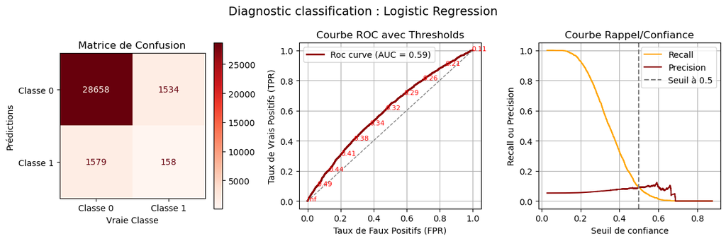

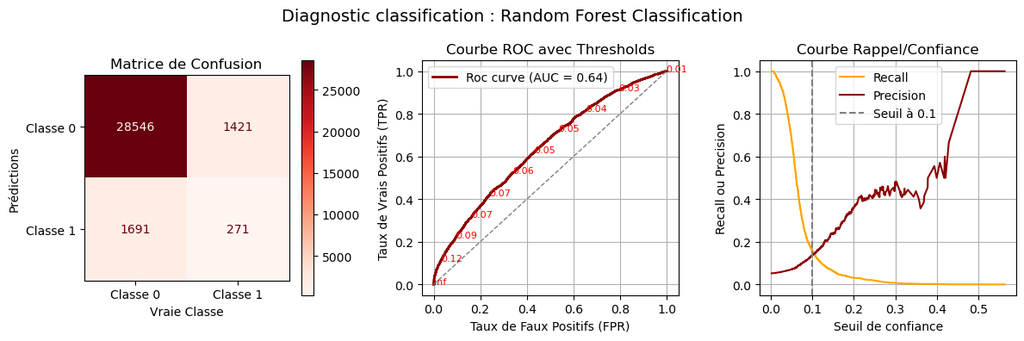

```python
logRegMonitor.plot_classification_diagnostics()
RFMonitor.plot_classification_diagnostics(threshold=0.10)
```

## resultats des modèles de sévérité ($c_i$)

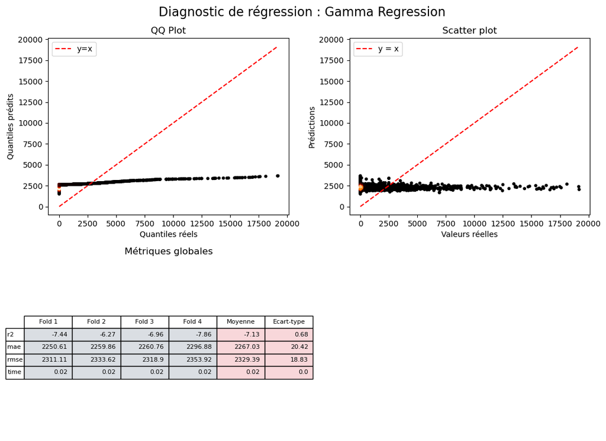

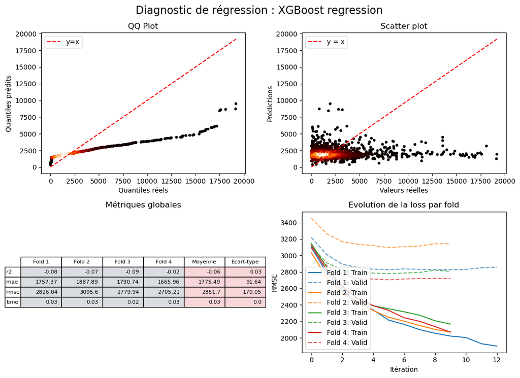

```python
GammaRegMonitor.plot_regression_diagnostics()
xgbMonitor.plot_regression_diagnostics()
```

## resultats des modèles combinés : $c(i | X) = p_i * c_i$

Concaténation des bases de validation enrichies

```python
df_results = pd.concat(results,axis=0)
df_results.iloc[:,23:].head()
```

|  | couts | y | pred_y_LogReg | pred_y_RF | pred_c_GammaReg | pred_c_xgb | pred_prime_linear | pred_prime_ensemble |
| --- | --- | --- | --- | --- | --- | --- | --- | --- |
| 4818 | 0.0 | 0 | 0 | 0 | 2058.921393 | 1449.305908 | 5.0 | 5.0 |
| 10584 | 0.0 | 0 | 0 | 0 | 2063.587620 | 1944.708008 | 5.0 | 5.0 |
| 7553 | 0.0 | 0 | 0 | 0 | 2450.749764 | 1772.867554 | 5.0 | 5.0 |
| 34637 | 0.0 | 0 | 0 | 0 | 2194.835556 | 1460.853271 | 5.0 | 5.0 |
| 11521 | 0.0 | 0 | 0 | 0 | 2271.788684 | 1897.171875 | 5.0 | 5.0 |

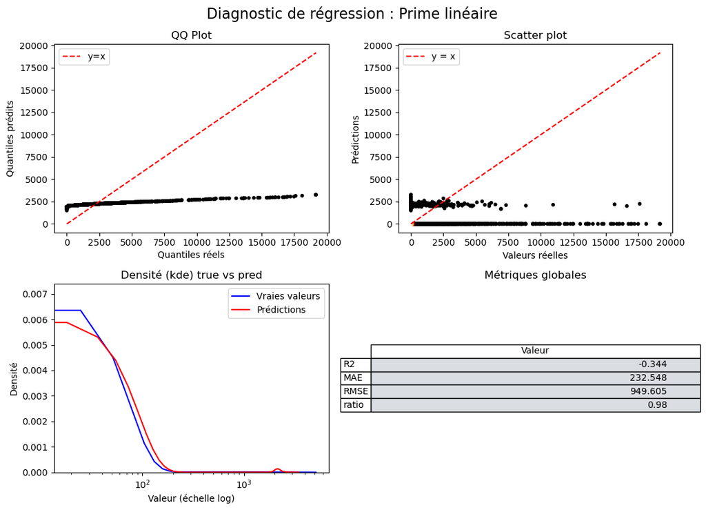

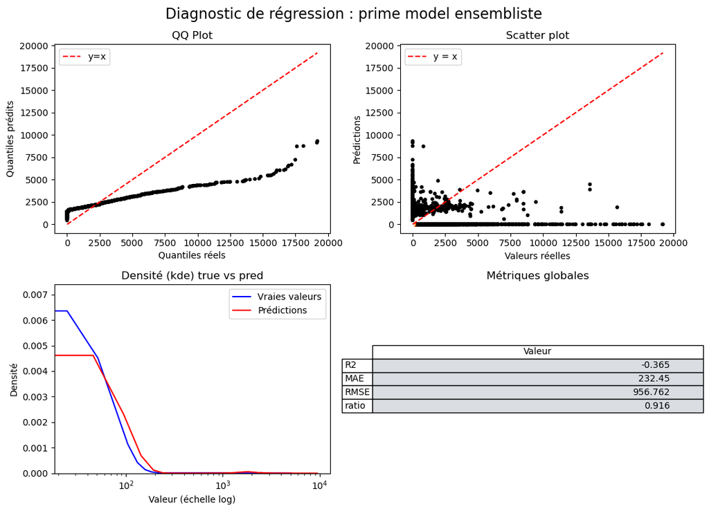

```python
plot_regression_diagnostics(df_results["couts"], df_results["pred_prime_linear"], model_name="Prime linéaire")
plot_regression_diagnostics(df_results["couts"], df_results["pred_prime_ensemble"], model_name="prime model ensembliste")
```

```python
df_results[['couts', 'y', 'pred_y_LogReg', 'pred_y_RF',
       'pred_c_GammaReg', 'pred_c_xgb', 'pred_prime_linear',
       'pred_prime_ensemble']].describe()
```

[output not shown]

## Interprétabilité et validation des modèles construits

### Explicabilité du model Linéair (logistic)

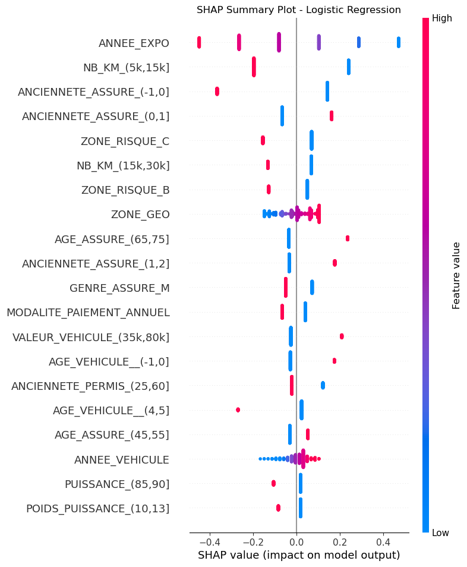

```python
import shap

# Calculer les valeurs SHAP sur un échantillon du jeu d'entraînement

X_sample = X_train.sample(500, random_state=42)
X_sample_transformed = logRegMonitor.models[-1].named_steps['preprocessor'].transform(X_sample)

# Créer l'explainer sur le modèle linéaire (attention: LinearExplainer pour la régression logistique)
explainer = shap.LinearExplainer(
	logRegMonitor.models[-1].named_steps['model'],
	X_sample_transformed,
	feature_names=feature_names
)
shap_values = explainer(X_sample_transformed)

# Afficher le summary plot SHAP
shap.summary_plot(shap_values, features=X_sample_transformed, feature_names=feature_names, show=False)
plt.title("SHAP Summary Plot - Logistic Regression")
plt.show()
```

### Coeficients du modèle linéaire (logistique) (20 premiers)

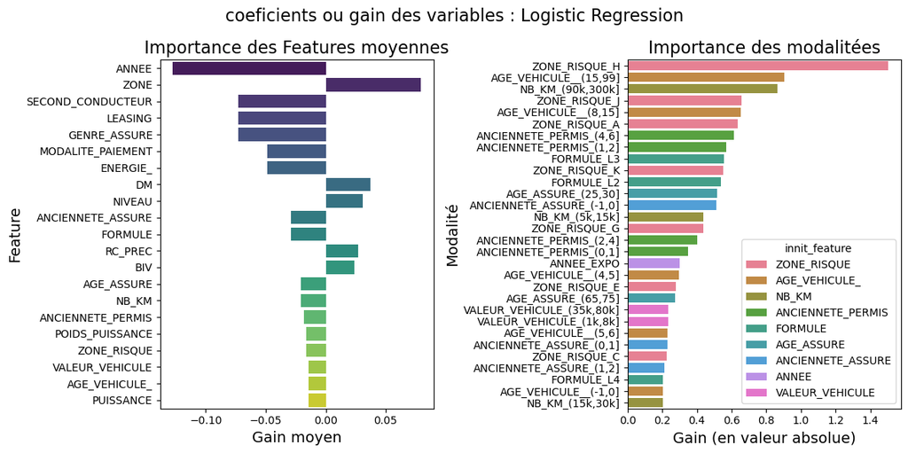

```python
# Récupérer le modèle de régression logistique entraîné
logreg_model = logRegMonitor.models[-1].named_steps['model']

# Créer un DataFrame des coefficients
df_coefs = pd.DataFrame({
    'Feature': feature_names,
    'Importance': logreg_model.coef_[0]
})

plot_importance(df_coefs, model_name="Logistic Regression")
```

### Explicabilité du model de Random Forests

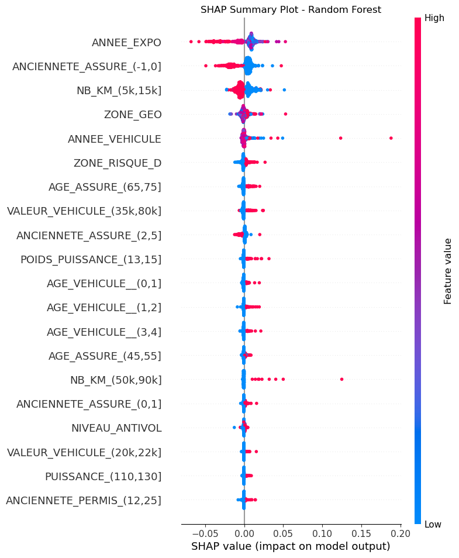

```python
import shap

# Prendre un échantillon du jeu d'entraînement pour l'explication
X_sample = X_train.sample(500, random_state=42)
X_sample_transformed = pipeline_RF.named_steps['preprocessor'].transform(X_sample)

# Créer l'explainer SHAP pour le modèle Random Forest du pipeline
explainer_rf = shap.TreeExplainer(pipeline_RF.named_steps['model'])
shap_values_rf = explainer_rf.shap_values(X_sample_transformed)

# Récupérer les noms de features après transformation
cat_feature_names = pipeline_RF.named_steps['preprocessor'].named_transformers_['cat'].named_steps['onehot'].get_feature_names_out(variables_cat)
feature_names_rf = variables_num + list(cat_feature_names)

# Afficher le summary plot SHAP
shap.summary_plot(shap_values_rf, features=X_sample_transformed, feature_names=feature_names_rf, show=False)
plt.title("SHAP Summary Plot - Random Forest")
plt.show()
```

### Explicabilité du model XGB

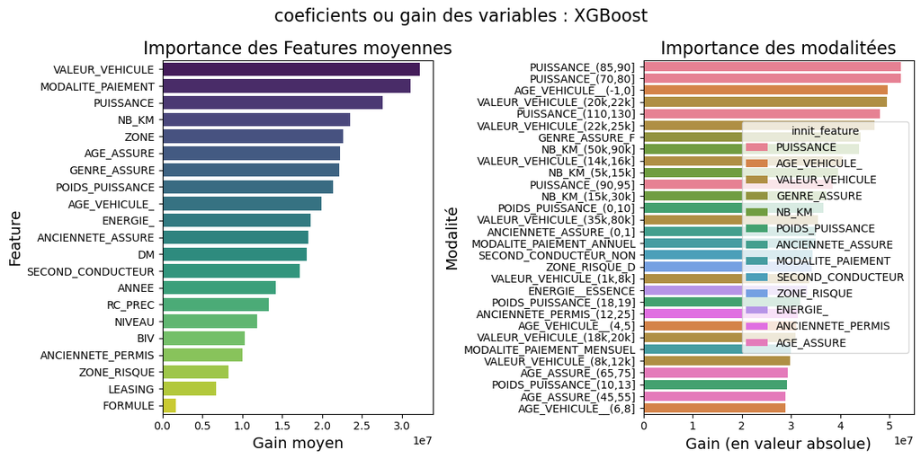

```python
booster = xgbMonitor.models[-1].get_booster()
importance_dict = booster.get_score(importance_type='gain')  # importance par 'gain'

importance_df = pd.DataFrame({
        'Feature': feature_names,
        'Importance': [importance_dict.get(f'f{i}', 0) for i in range(len(feature_names))]
})

plot_importance(importance_df, model_name="XGBoost")
```

## Performance par segment

Changez les segments à votre guise pour analyser les résultats ou pour combiner des modèles et ainsi performer la prédiction des primes

```python
from sklearn.metrics import root_mean_squared_error, f1_score

def compute_segment_metrics(df, segmentation, pred_y_col, pred_c_col, pred_prime_col,
                            y_col='y', couts_col='couts'):
    df1 = df[segmentation + [y_col, pred_y_col]].groupby(segmentation)\
        .apply(lambda x: f1_score(x[y_col], x[pred_y_col], zero_division=False), include_groups=False).reset_index()
    df2 = df[segmentation + [couts_col, pred_c_col]].groupby(segmentation)\
        .apply(lambda x: root_mean_squared_error(x[couts_col], x[pred_c_col]), include_groups=False).reset_index()
    df3 = df[segmentation + [couts_col, pred_prime_col]].groupby(segmentation)\
        .apply(lambda x: root_mean_squared_error(x[couts_col], x[pred_prime_col]), include_groups=False).reset_index()
    df4 = df[segmentation + [couts_col]].groupby(segmentation).count().reset_index()

    df1.columns = segmentation + ['f1_score']
    df2.columns = segmentation + ['rmse_c']
    df3.columns = segmentation + ['rmse_prime']
    df4.columns = segmentation + ['count']

    df_metrics = df1.merge(df2).merge(df3).merge(df4)
    return df_metrics
```

```python
df_segmented_linear = compute_segment_metrics(df_results, ['GENRE_ASSURE', 'ANCIENNETE_PERMIS'], pred_y_col='pred_y_LogReg', pred_c_col='pred_c_GammaReg', pred_prime_col='pred_prime_linear')
df_segmented_linear
```

|  | GENRE_ASSURE | ANCIENNETE_PERMIS | f1_score | rmse_c | rmse_prime | count |
| --- | --- | --- | --- | --- | --- | --- |
| 0 | F | (0,1] | 0.000000 | 2183.008876 | 5.000000 | 3 |
| 1 | F | (1,2] | 0.000000 | 2233.653308 | 5.000000 | 8 |
| 2 | F | (12,25] | 0.130548 | 2228.847776 | 911.149186 | 2993 |
| 3 | F | (2,4] | 0.000000 | 2656.431789 | 2047.650035 | 44 |
| 4 | F | (25,60] | 0.079349 | 2264.061684 | 844.186473 | 9897 |
| 5 | F | (4,6] | 0.000000 | 2184.259960 | 827.689760 | 102 |
| 6 | F | (6,8] | 0.000000 | 2226.564669 | 596.030069 | 218 |
| 7 | F | (8,12] | 0.118812 | 2217.769593 | 923.823390 | 604 |
| 8 | M | (0,1] | 0.000000 | 2100.293842 | 5.000000 | 1 |
| 9 | M | (12,25] | 0.060403 | 2371.019751 | 994.118098 | 2874 |
| 10 | M | (2,4] | 0.000000 | 2140.164273 | 1471.596577 | 12 |
| 11 | M | (25,60] | 0.093872 | 2389.078715 | 1011.046439 | 14508 |
| 12 | M | (4,6] | 0.222222 | 2227.872673 | 877.911846 | 39 |
| 13 | M | (6,8] | 0.000000 | 2274.066666 | 356.778599 | 164 |
| 14 | M | (8,12] | 0.179104 | 2412.202784 | 1194.577986 | 462 |

```python
df_segmented_ensemble = compute_segment_metrics(df_results, ['GENRE_ASSURE', 'ANCIENNETE_PERMIS'], pred_y_col='pred_y_RF', pred_c_col='pred_c_xgb', pred_prime_col='pred_prime_ensemble')
df_segmented_ensemble
```

|  | GENRE_ASSURE | ANCIENNETE_PERMIS | f1_score | rmse_c | rmse_prime | count |
| --- | --- | --- | --- | --- | --- | --- |
| 0 | F | (0,1] | 0.000000 | 1955.050301 | 5.000000 | 3 |
| 1 | F | (1,2] | 0.000000 | 1703.783739 | 5.000000 | 8 |
| 2 | F | (12,25] | 0.148571 | 2072.723665 | 860.702775 | 2993 |
| 3 | F | (2,4] | 0.000000 | 3712.003157 | 2260.454750 | 44 |
| 4 | F | (25,60] | 0.146341 | 2158.618707 | 828.125270 | 9897 |
| 5 | F | (4,6] | 0.000000 | 1992.426228 | 760.644070 | 102 |
| 6 | F | (6,8] | 0.114286 | 1992.591096 | 895.768938 | 218 |
| 7 | F | (8,12] | 0.203704 | 2118.422247 | 898.967771 | 604 |
| 8 | M | (0,1] | 0.000000 | 1557.280396 | 5.000000 | 1 |
| 9 | M | (12,25] | 0.137056 | 2293.068560 | 1037.782453 | 2874 |
| 10 | M | (2,4] | 0.000000 | 3111.520064 | 2214.169035 | 12 |
| 11 | M | (25,60] | 0.144638 | 2327.658987 | 1020.112425 | 14508 |
| 12 | M | (4,6] | 0.400000 | 2261.670842 | 865.857027 | 39 |
| 13 | M | (6,8] | 0.137931 | 2054.080520 | 683.566207 | 164 |
| 14 | M | (8,12] | 0.242991 | 2460.643087 | 1410.214325 | 462 |

## Prédiction sur la base de test

```python
#Comment prédire sur la base de test ?
pipeline_LogReg.fit(X_train,y_train)
pred_logreg = pipeline_LogReg.predict_proba(X_test)[:, 1]
y_pred_logreg = (pred_logreg > 0.5).astype(int)

pipeline_GammaReg.fit(X_train[y_train>0],couts_train[y_train>0])
c_pred_gammareg = pipeline_GammaReg.predict(X_test)

df_TEST = X_test.copy()
df_TEST['cout'] = couts_test
df_TEST['y'] = (couts_test > 0).astype(int)
df_TEST['pred_y_logreg'] = y_pred_logreg
df_TEST['pred_c_gammareg'] = c_pred_gammareg
df_TEST['pred_prime_linear'] = [max(5,x) for x in (y_pred_logreg * c_pred_gammareg)]
```

```python
# Fit the RF pipeline as before
pipeline_RF.fit(X_train, y_train)
pred_rf = pipeline_RF.predict(X_test)
y_pred_rf = (pred_rf > 0.1001).astype(int)

# Fit the XGBoost model as before
X_test_transformed = column_transformer.transform(X_test)
X_train_transformed_positive = column_transformer.transform(X_train[y_train > 0])

xgbReg_model.fit(
    X_train_transformed_positive,
    couts_train[y_train > 0],
    eval_set=[(X_train_transformed_positive, couts_train[y_train > 0]), (X_test_transformed[y_test > 0], couts_test[y_test > 0])],
    verbose=False
)
c_pred_xgb = xgbReg_model.predict(X_test_transformed)

df_TEST['pred_y_rf'] = y_pred_rf
df_TEST['pred_c_xgb'] = c_pred_xgb
df_TEST['pred_prime_ensemble'] = [max(5, x) for x in (y_pred_rf * c_pred_xgb)]
```

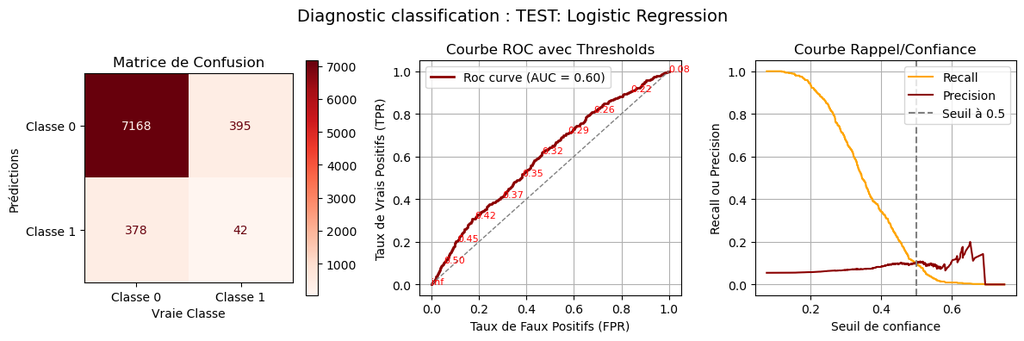

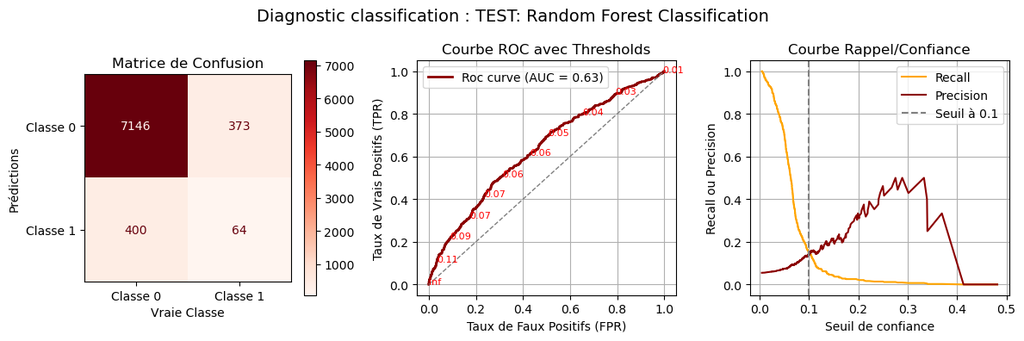

```python
plot_classification_diagnostics(df_TEST['y'], pred_logreg, model_name="TEST: Logistic Regression", threshold=0.5)
plot_classification_diagnostics(df_TEST['y'], pred_rf, model_name="TEST: Random Forest Classification", threshold=0.10)
```

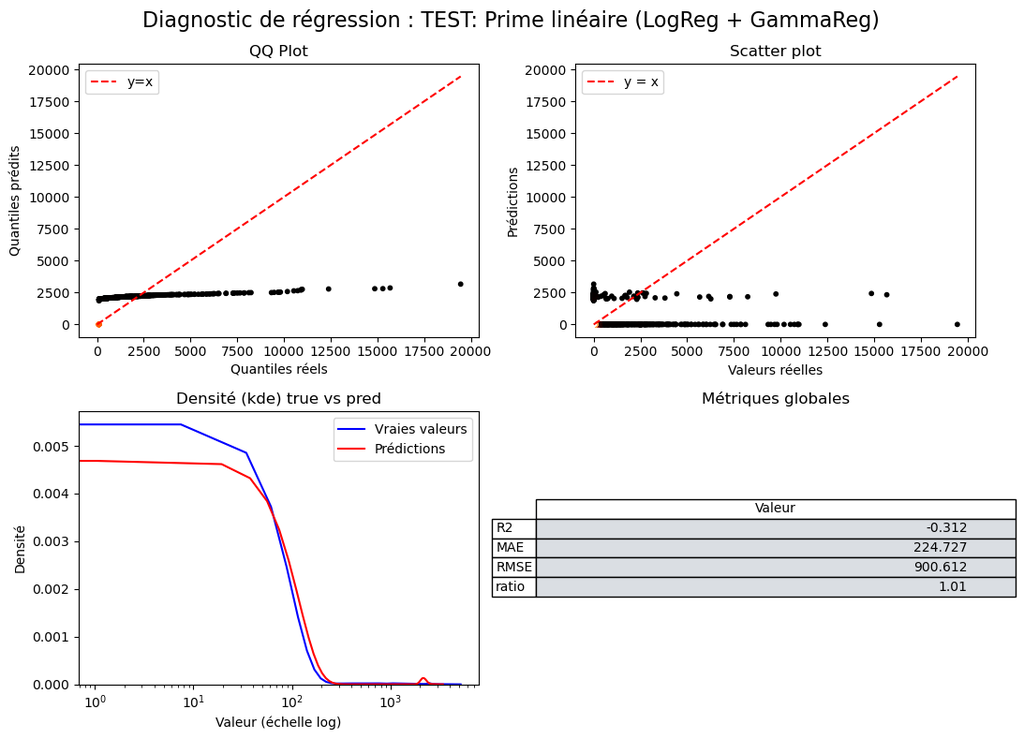

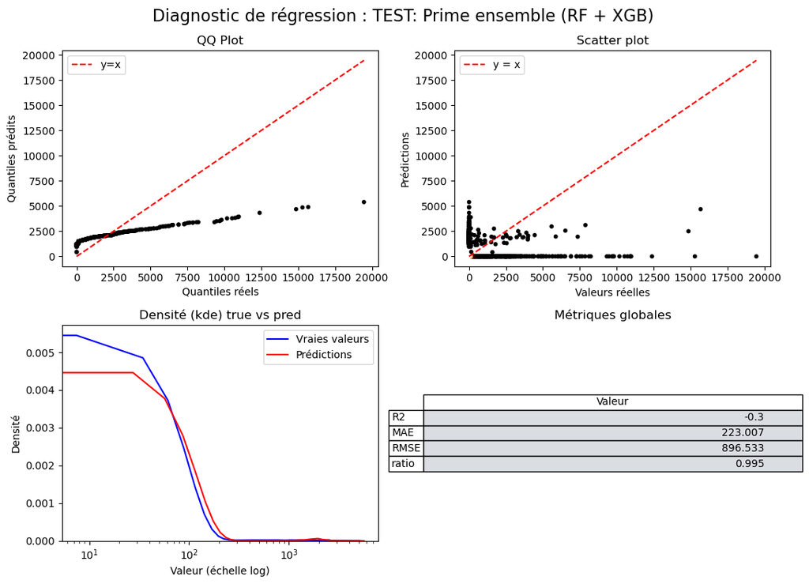

```python
plot_regression_diagnostics(df_TEST["cout"], df_TEST["pred_prime_linear"], model_name="TEST: Prime linéaire (LogReg + GammaReg)")
plot_regression_diagnostics(df_TEST["cout"], df_TEST["pred_prime_ensemble"], model_name="TEST: Prime ensemble (RF + XGB)")
```

# Conclusion

### Typologie de modèle

J'ai choisi d'améliorer le modèle sinistre*sevérité (2), étant donné une baseline fonctionnelle, et des premiers tests concluants.

### data processing

Le jeu de donnée d'entrée était plutôt propre et peu de processing a été effectué, hormis l'encodage et typage des variables.

Les pipelines scikitlearn sont interessants mais piégeux et finalement peu utiles si l'on veut vraiment maitriser son code (surtout avec des process customisés). Il est embêtant lors d'un .fit() de réentrainer le préprocesseur quand celui-ci est sensé être immuable.

->Améliorations possibles :

- On pourra cependant l'améliorer avec de l'over/under sampling, prévu pour rééquilibrer les variables à expliquer Y.
- D'autres approches de scaling (min-max) et d'imputation (knn) auraient pu être envisagées, mais celles indiquées étaient déjà suffisantes.
- Avec une meilleure connaissance du métier, un meilleur feature engineering aurait pu être envisagé.

### performances du model

->Améliorations possibles :

- On pourra cependant l'améliorer le paramétrage des hyperparamètres, (HPO) avec plus de temps et l'utilisation de Grid/RandomSearch. Certains paramètres sont ajustables à la main et dépendent du context de données, certains sont nécessairement à ajuster à l'aide d'experiences.
- On pourrait envisager d'autres types de modèles, comme les SVM, ou réseau de neurones ou autres.. mes nombreux tests n'ont pas montré quelque chose de satisfaisant...(l'hyperparamètrage est sensible)